# CIND 123: Data Analytics Basic Methods: Assignment-3

# Assignment 3 (10%)

## Total 100 Marks

### [Stephanie Boissonneault]

## Instructions

Use RStudio for this assignment. Complete the assignment by inserting your R code wherever you see the string “#INSERT YOUR ANSWER HERE”.

Submit **both** the rmd and generated output files. Failing to submit both files will be subject to mark deduction.

## Sample Question and Solution

Use `seq()` to create the vector $(2,4,6,\ldots,20)$.

```r
#INSERT YOUR ANSWER HERE.
seq(2,20,by = 2)
```

```
##  [1]  2  4  6  8 10 12 14 16 18 20
```

## Question 1 [15 Pts]

1. [5 Pts] First and second midterm grades of some students are given as c(85,76,78,88,90,95,42,31,66) and c(55,66,48,58,80,75,32,22,39). Set R variables `first` and `second` respectively. Then find the least-squares line relating the second midterm to the first midterm.

   Does the assumption of a linear relationship appear to be reasonable in this case? Give reasons to your answer as a comment.

```r
first <- c(85,76,78,88,90,95,42,31,66)
second <- c(55,66,48,58,80,75,32,22,39)

lsmodel <- lm(second ~ first)
summary(lsmodel)
```

```
##
## Call:
## lm(formula = second ~ first)
##
## Residuals:
##    Min     1Q Median     3Q    Max
## -9.238 -7.747  1.753  4.383 13.318
##
## Coefficients:
##             Estimate Std. Error t value Pr(>|t|)
## (Intercept)  -4.1516    10.9987  -0.377  0.71702
## first         0.7870     0.1461   5.389  0.00102 **
## ---
## Signif. codes:  0 '***' 0.001 '**' 0.01 '*' 0.05 '.' 0.1 ' ' 1
##
## Residual standard error: 9.175 on 7 degrees of freedom
## Multiple R-squared:  0.8058, Adjusted R-squared:  0.778
## F-statistic: 29.04 on 1 and 7 DF,  p-value: 0.001021
```

```r
#The assumption of a linear relationship appears to be reasonable because the summary of the line of best fit has a p value = 0.001 indicating that the overall model is statistically significant. In addition, the adjusted R squared value is 0.778 (this is fairly high and close to 1, indicating that the independent variables of the model can well predict the variation of the predicted variables). Here the residuals range from -9 to 13 which is a fairly symmetrical distribution. This model demonstrates that the line of best fit has a y intercept of -4.15. For every increase in one mark form the first midterm grade, the second midterm grade increases by about 0.79 (this is the slope).
```

2. [5 Pts] Plot the second midterm as a function of the first midterm using a scatterplot and graph the least-square line in red color on the same plot.

```r
print(plot(first, second, main = "First and second midterm grades of some students"))
```

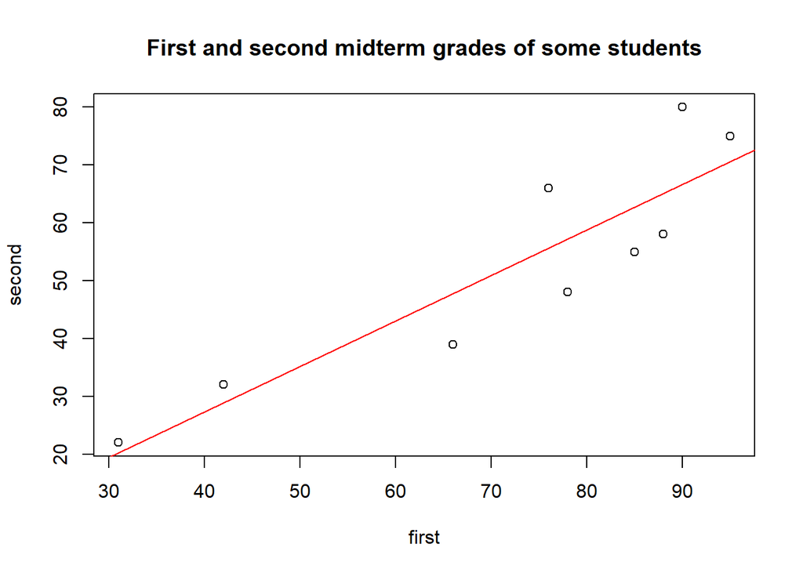

```r
print(abline(lsmodel, col = "red"))
```

3. [5 Pts] Use the regression line to predict the second midterm grades when the first midterm grades are 81 and 23.

```r
first.81 <- data.frame(first=c(81))
predict(lsmodel, first.81)
```

```
##        1
## 59.59881
```

```r
first.23 <- data.frame(first=c(23))
predict(lsmodel, first.23)
```

```
##        1
## 13.95039
```

## Question 2 [45 Pts]

This question makes use of package “plm”. Please load Crime dataset as follows:

```r
#install.packages("plm")
library(plm)
data(Crime)
```

1. [5 Pts] Display the first 8 rows of ‘crime’ data and display the names of all the variables, the number of variables, then display a descriptive summary of each variable.

```r
#Display first 8 rows
print(head(Crime, 8))
```

```
##   county year    crmrte   prbarr  prbconv  prbpris avgsen     polpc  density
## 1      1   81 0.0398849 0.289696 0.402062 0.472222   5.61 0.0017868 2.307159
## 2      1   82 0.0383449 0.338111 0.433005 0.506993   5.59 0.0017666 2.330254
## 3      1   83 0.0303048 0.330449 0.525703 0.479705   5.80 0.0018358 2.341801
## 4      1   84 0.0347259 0.362525 0.604706 0.520104   6.89 0.0018859 2.346420
## 5      1   85 0.0365730 0.325395 0.578723 0.497059   6.55 0.0019244 2.364896
## 6      1   86 0.0347524 0.326062 0.512324 0.439863   6.90 0.0018952 2.385681
## 7      1   87 0.0356036 0.298270 0.527596 0.436170   6.71 0.0018279 2.422633
## 8      3   81 0.0163921 0.202899 0.869048 0.465753   8.45 0.0005939 0.976834
##      taxpc  region smsa   pctmin     wcon      wtuc     wtrd     wfir     wser
## 1 25.69763 central   no 20.21870 206.4803  333.6209 182.3330 272.4492 215.7335
## 2 24.87425 central   no 20.21870 212.7542  369.2964 189.5414 300.8788 231.5767
## 3 26.45144 central   no 20.21870 219.7802 1394.8030 196.6395 309.9696 240.1568
## 4 26.84235 central   no 20.21870 223.4238  398.8604 200.5629 350.0863 252.4477
## 5 28.14034 central   no 20.21870 243.7562  358.7830 206.8827 383.0707 261.0861
```

[output cut: 39 more lines]

```r
#Display all variable names
print(ls(Crime))
```

```
##  [1] "avgsen"   "county"   "crmrte"   "density"  "lavgsen"  "lcrmrte"
##  [7] "ldensity" "lmix"     "lpctmin"  "lpctymle" "lpolpc"   "lprbarr"
## [13] "lprbconv" "lprbpris" "ltaxpc"   "lwcon"    "lwfed"    "lwfir"
## [19] "lwloc"    "lwmfg"    "lwser"    "lwsta"    "lwtrd"    "lwtuc"
## [25] "mix"      "pctmin"   "pctymle"  "polpc"    "prbarr"   "prbconv"
## [31] "prbpris"  "region"   "smsa"     "taxpc"    "wcon"     "wfed"
## [37] "wfir"     "wloc"     "wmfg"     "wser"     "wsta"     "wtrd"
## [43] "wtuc"     "year"
```

```r
#Display number of variables
print(length(ls(Crime)))
```

```
## [1] 44
```

```r
#Display each variable's descriptive summary
print(summary(Crime))
```

```
##      county           year        crmrte             prbarr
##  Min.   :  1.0   Min.   :81   Min.   :0.001812   Min.   :0.05882
##  1st Qu.: 51.0   1st Qu.:82   1st Qu.:0.018352   1st Qu.:0.21790
##  Median :103.0   Median :84   Median :0.028441   Median :0.27824
##  Mean   :100.6   Mean   :84   Mean   :0.031588   Mean   :0.30737
##  3rd Qu.:151.0   3rd Qu.:86   3rd Qu.:0.038406   3rd Qu.:0.35252
##  Max.   :197.0   Max.   :87   Max.   :0.163835   Max.   :2.75000
##     prbconv            prbpris           avgsen           polpc
##  Min.   : 0.06838   Min.   :0.1489   Min.   : 4.220   Min.   :0.0004585
##  1st Qu.: 0.34769   1st Qu.:0.3744   1st Qu.: 7.160   1st Qu.:0.0011913
##  Median : 0.47437   Median :0.4286   Median : 8.495   Median :0.0014506
##  Mean   : 0.68862   Mean   :0.4255   Mean   : 8.955   Mean   :0.0019168
##  3rd Qu.: 0.63560   3rd Qu.:0.4832   3rd Qu.:10.197   3rd Qu.:0.0018033
##  Max.   :37.00000   Max.   :0.6786   Max.   :25.830   Max.   :0.0355781
##     density           taxpc            region     smsa         pctmin
##  Min.   :0.1977   Min.   : 14.30   other  :245   no :574   Min.   : 1.284
##  1st Qu.:0.5329   1st Qu.: 23.43   west   :147   yes: 56   1st Qu.:10.005
##  Median :0.9526   Median : 27.79   central:238             Median :24.852
##  Mean   :1.3861   Mean   : 30.24                           Mean   :25.713
##  3rd Qu.:1.5078   3rd Qu.: 33.27                           3rd Qu.:38.223
##  Max.   :8.8277   Max.   :119.76                           Max.   :64.348
##       wcon              wtuc              wtrd              wfir
##  Min.   :  65.62   Min.   :  28.86   Min.   :  16.87   Min.   :  3.516
##  1st Qu.: 201.66   1st Qu.: 317.60   1st Qu.: 168.05   1st Qu.:235.705
##  Median : 236.46   Median : 358.20   Median : 185.48   Median :264.423
##  Mean   : 245.67   Mean   : 406.10   Mean   : 192.82   Mean   :272.059
##  3rd Qu.: 269.69   3rd Qu.: 411.02   3rd Qu.: 204.82   3rd Qu.:302.440
##  Max.   :2324.60   Max.   :3041.96   Max.   :2242.75   Max.   :509.466
##       wser               wmfg            wfed            wsta
##  Min.   :   1.844   Min.   :101.8   Min.   :255.4   Min.   :173.0
##  1st Qu.: 191.319   1st Qu.:234.0   1st Qu.:361.5   1st Qu.:258.2
##  Median : 216.475   Median :271.6   Median :404.0   Median :289.4
##  Mean   : 224.671   Mean   :285.2   Mean   :403.9   Mean   :296.9
##  3rd Qu.: 247.155   3rd Qu.:320.0   3rd Qu.:444.6   3rd Qu.:331.5
##  Max.   :2177.068   Max.   :646.9   Max.   :598.0   Max.   :548.0
##       wloc            mix              pctymle           lcrmrte
##  Min.   :163.6   Min.   :0.002457   Min.   :0.06216   Min.   :-6.314
##  1st Qu.:226.8   1st Qu.:0.075324   1st Qu.:0.07859   1st Qu.:-3.998
##  Median :253.1   Median :0.102089   Median :0.08316   Median :-3.560
##  Mean   :258.0   Mean   :0.139396   Mean   :0.08897   Mean   :-3.609
```

[output cut: 22 more lines]

```
##  Max.   :7.715   Max.   :6.233   Max.   :7.6857   Max.   :6.472
##      lwfed           lwsta           lwloc          lpctymle
##  Min.   :5.543   Min.   :5.153   Min.   :5.097   Min.   :-2.778
##  1st Qu.:5.890   1st Qu.:5.554   1st Qu.:5.424   1st Qu.:-2.543
##  Median :6.001   Median :5.668   Median :5.534   Median :-2.487
##  Mean   :5.989   Mean   :5.678   Mean   :5.540   Mean   :-2.443
##  3rd Qu.:6.097   3rd Qu.:5.804   3rd Qu.:5.667   3rd Qu.:-2.417
##  Max.   :6.394   Max.   :6.306   Max.   :5.961   Max.   :-1.293
##     lpctmin           ltaxpc           lmix
##  Min.   :0.2497   Min.   :2.660   Min.   :-6.009
##  1st Qu.:2.3030   1st Qu.:3.154   1st Qu.:-2.586
##  Median :3.2127   Median :3.325   Median :-2.282
##  Mean   :2.9134   Mean   :3.356   Mean   :-2.234
##  3rd Qu.:3.6434   3rd Qu.:3.505   3rd Qu.:-1.904
##  Max.   :4.1643   Max.   :4.786   Max.   : 1.386
```

2. [5 Pts] Calculate the mean,variance and standard deviation of probability of arrest (prbarr) by omitting the missing values, if any.

```r
#mean
prbarr_avg <- mean(Crime$prbarr, na.rm = TRUE)
prbarr_avg
```

```
## [1] 0.3073682
```

```r
#variance
prbarr_var <- var(Crime$prbarr, na.rm = TRUE)
prbarr_var
```

```
## [1] 0.02931104
```

```r
#standard deviation
prbarr_sd <- sqrt(prbarr_var)
prbarr_sd
```

```
## [1] 0.1712047
```

3. [5 Pts] Use `lpolpc` (log-police per capita) and `smsa` variables to build a linear regression model to predict probability of arrest (prbarr). And, compare with another linear regression model that uses `polpc` (police per capita) and `smsa`.